# Risk Factor Analysis

## Outcome Variable

**Outcome Variable:** pers_wast

## Predictor Variables

**Intervention Variable:** predexfd6

**Adjustment Set:**

unadjusted

## Stratifying Variables

The analysis was stratified on these variable(s):

- agecat
- studyid
- country

## Data Summary

| agecat | studyid | country | predexfd6 | pers_wast | n_cell | n |
| --- | --- | --- | --- | --- | --- | --- |
| 0-24 months | ki0047075b-MAL-ED | BANGLADESH | 0 | 0 | 108 | 238 |
| 0-24 months | ki0047075b-MAL-ED | BANGLADESH | 0 | 1 | 5 | 238 |
| 0-24 months | ki0047075b-MAL-ED | BANGLADESH | 1 | 0 | 117 | 238 |
| 0-24 months | ki0047075b-MAL-ED | BANGLADESH | 1 | 1 | 8 | 238 |
| 0-24 months | ki0047075b-MAL-ED | BRAZIL | 0 | 0 | 175 | 212 |
| 0-24 months | ki0047075b-MAL-ED | BRAZIL | 0 | 1 | 1 | 212 |
| 0-24 months | ki0047075b-MAL-ED | BRAZIL | 1 | 0 | 35 | 212 |
| 0-24 months | ki0047075b-MAL-ED | BRAZIL | 1 | 1 | 1 | 212 |
| 0-24 months | ki0047075b-MAL-ED | INDIA | 0 | 0 | 196 | 234 |
| 0-24 months | ki0047075b-MAL-ED | INDIA | 0 | 1 | 19 | 234 |
| 0-24 months | ki0047075b-MAL-ED | INDIA | 1 | 0 | 19 | 234 |
| 0-24 months | ki0047075b-MAL-ED | INDIA | 1 | 1 | 0 | 234 |
| 0-24 months | ki0047075b-MAL-ED | NEPAL | 0 | 0 | 203 | 235 |
| 0-24 months | ki0047075b-MAL-ED | NEPAL | 0 | 1 | 3 | 235 |
| 0-24 months | ki0047075b-MAL-ED | NEPAL | 1 | 0 | 29 | 235 |
| 0-24 months | ki0047075b-MAL-ED | NEPAL | 1 | 1 | 0 | 235 |
| 0-24 months | ki0047075b-MAL-ED | PERU | 0 | 0 | 156 | 270 |
| 0-24 months | ki0047075b-MAL-ED | PERU | 0 | 1 | 0 | 270 |
| 0-24 months | ki0047075b-MAL-ED | PERU | 1 | 0 | 113 | 270 |
| 0-24 months | ki0047075b-MAL-ED | PERU | 1 | 1 | 1 | 270 |
| 0-24 months | ki0047075b-MAL-ED | SOUTH AFRICA | 0 | 0 | 243 | 248 |
| 0-24 months | ki0047075b-MAL-ED | SOUTH AFRICA | 0 | 1 | 2 | 248 |
| 0-24 months | ki0047075b-MAL-ED | SOUTH AFRICA | 1 | 0 | 3 | 248 |
| 0-24 months | ki0047075b-MAL-ED | SOUTH AFRICA | 1 | 1 | 0 | 248 |
| 0-24 months | ki0047075b-MAL-ED | TANZANIA, UNITED REPUBLIC OF | 0 | 0 | 246 | 248 |
| 0-24 months | ki0047075b-MAL-ED | TANZANIA, UNITED REPUBLIC OF | 0 | 1 | 0 | 248 |
| 0-24 months | ki0047075b-MAL-ED | TANZANIA, UNITED REPUBLIC OF | 1 | 0 | 2 | 248 |
| 0-24 months | ki0047075b-MAL-ED | TANZANIA, UNITED REPUBLIC OF | 1 | 1 | 0 | 248 |
| 0-24 months | ki1000108-CMC-V-BCS-2002 | INDIA | 0 | 0 | 0 | 19 |
| 0-24 months | ki1000108-CMC-V-BCS-2002 | INDIA | 0 | 1 | 0 | 19 |

[output cut: 162 more lines]

The following strata were considered:

- agecat: 0-24 months, studyid: ki0047075b-MAL-ED, country: BANGLADESH
- agecat: 0-24 months, studyid: ki0047075b-MAL-ED, country: BRAZIL
- agecat: 0-24 months, studyid: ki0047075b-MAL-ED, country: INDIA
- agecat: 0-24 months, studyid: ki0047075b-MAL-ED, country: NEPAL
- agecat: 0-24 months, studyid: ki0047075b-MAL-ED, country: PERU
- agecat: 0-24 months, studyid: ki0047075b-MAL-ED, country: SOUTH AFRICA
- agecat: 0-24 months, studyid: ki0047075b-MAL-ED, country: TANZANIA, UNITED REPUBLIC OF
- agecat: 0-24 months, studyid: ki1000108-CMC-V-BCS-2002, country: INDIA
- agecat: 0-24 months, studyid: ki1000108-IRC, country: INDIA
- agecat: 0-24 months, studyid: ki1000109-EE, country: PAKISTAN
- agecat: 0-24 months, studyid: ki1000304b-SAS-CompFeed, country: INDIA
- agecat: 0-24 months, studyid: ki1000304b-SAS-FoodSuppl, country: INDIA
- agecat: 0-24 months, studyid: ki1017093b-PROVIDE, country: BANGLADESH
- agecat: 0-24 months, studyid: ki1101329-Keneba, country: GAMBIA
- agecat: 0-24 months, studyid: ki1113344-GMS-Nepal, country: NEPAL
- agecat: 0-24 months, studyid: ki1148112-LCNI-5, country: MALAWI
- agecat: 0-24 months, studyid: kiGH5241-JiVitA-3, country: BANGLADESH
- agecat: 0-24 months, studyid: kiGH5241-JiVitA-4, country: BANGLADESH
- agecat: 0-6 months, studyid: ki0047075b-MAL-ED, country: BANGLADESH
- agecat: 0-6 months, studyid: ki0047075b-MAL-ED, country: BRAZIL
- agecat: 0-6 months, studyid: ki0047075b-MAL-ED, country: INDIA
- agecat: 0-6 months, studyid: ki0047075b-MAL-ED, country: NEPAL
- agecat: 0-6 months, studyid: ki0047075b-MAL-ED, country: PERU
- agecat: 0-6 months, studyid: ki0047075b-MAL-ED, country: SOUTH AFRICA
- agecat: 0-6 months, studyid: ki0047075b-MAL-ED, country: TANZANIA, UNITED REPUBLIC OF
- agecat: 0-6 months, studyid: ki1000108-CMC-V-BCS-2002, country: INDIA
- agecat: 0-6 months, studyid: ki1000108-IRC, country: INDIA
- agecat: 0-6 months, studyid: ki1000109-EE, country: PAKISTAN
- agecat: 0-6 months, studyid: ki1017093b-PROVIDE, country: BANGLADESH
- agecat: 0-6 months, studyid: ki1101329-Keneba, country: GAMBIA
- agecat: 0-6 months, studyid: ki1113344-GMS-Nepal, country: NEPAL
- agecat: 6-24 months, studyid: ki0047075b-MAL-ED, country: BANGLADESH
- agecat: 6-24 months, studyid: ki0047075b-MAL-ED, country: BRAZIL
- agecat: 6-24 months, studyid: ki0047075b-MAL-ED, country: INDIA
- agecat: 6-24 months, studyid: ki0047075b-MAL-ED, country: NEPAL
- agecat: 6-24 months, studyid: ki0047075b-MAL-ED, country: PERU
- agecat: 6-24 months, studyid: ki0047075b-MAL-ED, country: SOUTH AFRICA
- agecat: 6-24 months, studyid: ki0047075b-MAL-ED, country: TANZANIA, UNITED REPUBLIC OF
- agecat: 6-24 months, studyid: ki1000108-CMC-V-BCS-2002, country: INDIA
- agecat: 6-24 months, studyid: ki1000108-IRC, country: INDIA
- agecat: 6-24 months, studyid: ki1000109-EE, country: PAKISTAN
- agecat: 6-24 months, studyid: ki1000304b-SAS-CompFeed, country: INDIA
- agecat: 6-24 months, studyid: ki1000304b-SAS-FoodSuppl, country: INDIA
- agecat: 6-24 months, studyid: ki1017093b-PROVIDE, country: BANGLADESH
- agecat: 6-24 months, studyid: ki1101329-Keneba, country: GAMBIA
- agecat: 6-24 months, studyid: ki1113344-GMS-Nepal, country: NEPAL
- agecat: 6-24 months, studyid: ki1148112-LCNI-5, country: MALAWI
- agecat: 6-24 months, studyid: kiGH5241-JiVitA-4, country: BANGLADESH

### Dropped Strata

Some strata were dropped due to rare outcomes:

- agecat: 0-24 months, studyid: ki0047075b-MAL-ED, country: BRAZIL
- agecat: 0-24 months, studyid: ki0047075b-MAL-ED, country: INDIA
- agecat: 0-24 months, studyid: ki0047075b-MAL-ED, country: NEPAL
- agecat: 0-24 months, studyid: ki0047075b-MAL-ED, country: PERU
- agecat: 0-24 months, studyid: ki0047075b-MAL-ED, country: SOUTH AFRICA
- agecat: 0-24 months, studyid: ki0047075b-MAL-ED, country: TANZANIA, UNITED REPUBLIC OF
- agecat: 0-24 months, studyid: ki1000108-CMC-V-BCS-2002, country: INDIA
- agecat: 0-24 months, studyid: ki1000108-IRC, country: INDIA
- agecat: 0-24 months, studyid: ki1000304b-SAS-CompFeed, country: INDIA
- agecat: 0-24 months, studyid: ki1000304b-SAS-FoodSuppl, country: INDIA
- agecat: 0-24 months, studyid: ki1017093b-PROVIDE, country: BANGLADESH
- agecat: 0-24 months, studyid: ki1148112-LCNI-5, country: MALAWI
- agecat: 0-6 months, studyid: ki0047075b-MAL-ED, country: BANGLADESH
- agecat: 0-6 months, studyid: ki0047075b-MAL-ED, country: BRAZIL
- agecat: 0-6 months, studyid: ki0047075b-MAL-ED, country: INDIA
- agecat: 0-6 months, studyid: ki0047075b-MAL-ED, country: NEPAL
- agecat: 0-6 months, studyid: ki0047075b-MAL-ED, country: PERU
- agecat: 0-6 months, studyid: ki0047075b-MAL-ED, country: SOUTH AFRICA
- agecat: 0-6 months, studyid: ki0047075b-MAL-ED, country: TANZANIA, UNITED REPUBLIC OF
- agecat: 0-6 months, studyid: ki1000108-CMC-V-BCS-2002, country: INDIA
- agecat: 0-6 months, studyid: ki1000108-IRC, country: INDIA
- agecat: 0-6 months, studyid: ki1017093b-PROVIDE, country: BANGLADESH
- agecat: 6-24 months, studyid: ki0047075b-MAL-ED, country: BRAZIL
- agecat: 6-24 months, studyid: ki0047075b-MAL-ED, country: INDIA
- agecat: 6-24 months, studyid: ki0047075b-MAL-ED, country: NEPAL
- agecat: 6-24 months, studyid: ki0047075b-MAL-ED, country: PERU
- agecat: 6-24 months, studyid: ki0047075b-MAL-ED, country: SOUTH AFRICA
- agecat: 6-24 months, studyid: ki0047075b-MAL-ED, country: TANZANIA, UNITED REPUBLIC OF
- agecat: 6-24 months, studyid: ki1000108-CMC-V-BCS-2002, country: INDIA
- agecat: 6-24 months, studyid: ki1000108-IRC, country: INDIA
- agecat: 6-24 months, studyid: ki1000304b-SAS-CompFeed, country: INDIA
- agecat: 6-24 months, studyid: ki1000304b-SAS-FoodSuppl, country: INDIA
- agecat: 6-24 months, studyid: ki1148112-LCNI-5, country: MALAWI

## Methods Detail

We’re interested in the causal parameters $E[Y_a]$ for all values of $a \in \mathcal{A}$. These parameters represent the mean outcome if, possibly contrary to fact, we intervened to set all units to have $A=a$. Under the randomization and positivity assumptions, these are identified by the statistical parameters $\psi_a=E_W[E_{Y|A,W}(Y|A=a,W)]$. In addition, we’re interested in the mean of $Y$, $E[Y]$ under no intervention (the observed mean). We will estimate these parameters by using SuperLearner to fit the relevant likelihood factors – $E_{Y|A,W}(Y|A=a,W)$ and $p(A=a|W)$, and then updating our likelihood fit using a joint TMLE.

For unadjusted analyses ($W=\{\}$), initial likelihoods were estimated using Lrnr_glm to estimate the simple $E(Y|A)$ and Lrnr_mean to estimate $p(A)$. For adjusted analyses, a small library containing Lrnr_glmnet, Lrnr_xgboost, and Lrnr_mean was used.

Having estimated these parameters, we will then use the delta method to estimate relative risks and attributable risks relative to a prespecified baseline level of $A$.

# Results Detail

## Results Plots

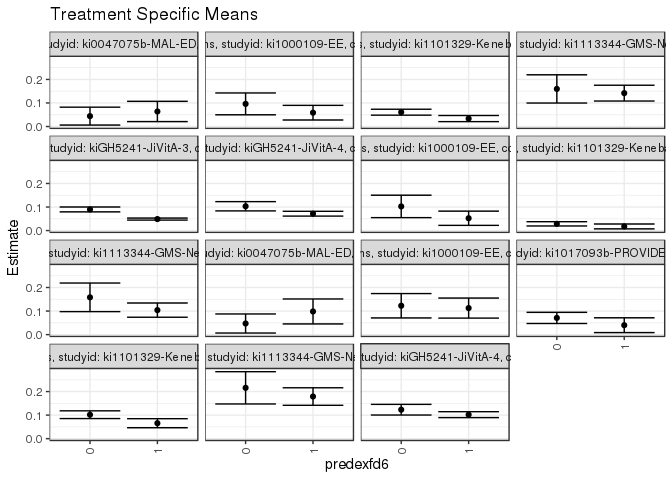

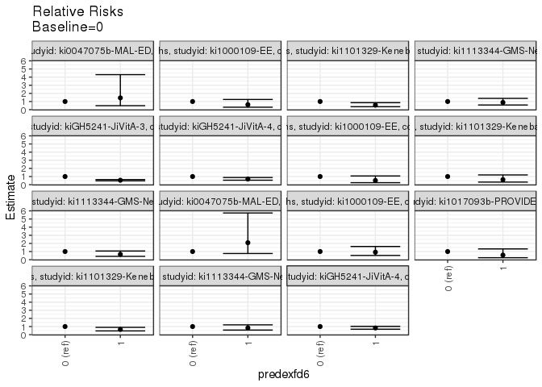

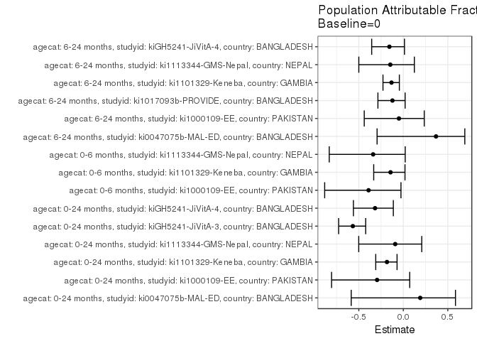

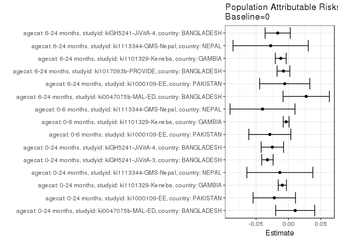

## Results Table

### Parameter: TSM

| agecat | studyid | country | intervention_level | baseline_level | estimate | ci_lower | ci_upper |
| --- | --- | --- | --- | --- | --- | --- | --- |
| 0-24 months | ki0047075b-MAL-ED | BANGLADESH | 0 | NA | 0.0442478 | 0.0062515 | 0.0822441 |
| 0-24 months | ki0047075b-MAL-ED | BANGLADESH | 1 | NA | 0.0640000 | 0.0210033 | 0.1069967 |
| 0-24 months | ki1000109-EE | PAKISTAN | 0 | NA | 0.0961538 | 0.0498312 | 0.1424765 |
| 0-24 months | ki1000109-EE | PAKISTAN | 1 | NA | 0.0588235 | 0.0277608 | 0.0898863 |
| 0-24 months | ki1101329-Keneba | GAMBIA | 0 | NA | 0.0608696 | 0.0482520 | 0.0734871 |
| 0-24 months | ki1101329-Keneba | GAMBIA | 1 | NA | 0.0337838 | 0.0207633 | 0.0468042 |
| 0-24 months | ki1113344-GMS-Nepal | NEPAL | 0 | NA | 0.1597222 | 0.0998329 | 0.2196115 |
| 0-24 months | ki1113344-GMS-Nepal | NEPAL | 1 | NA | 0.1418269 | 0.1082720 | 0.1753819 |
| 0-24 months | kiGH5241-JiVitA-3 | BANGLADESH | 0 | NA | 0.0897833 | 0.0794424 | 0.1001242 |
| 0-24 months | kiGH5241-JiVitA-3 | BANGLADESH | 1 | NA | 0.0488550 | 0.0445372 | 0.0531727 |
| 0-24 months | kiGH5241-JiVitA-4 | BANGLADESH | 0 | NA | 0.1032389 | 0.0836545 | 0.1228232 |
| 0-24 months | kiGH5241-JiVitA-4 | BANGLADESH | 1 | NA | 0.0716246 | 0.0614168 | 0.0818323 |
| 0-6 months | ki1000109-EE | PAKISTAN | 0 | NA | 0.1025641 | 0.0548904 | 0.1502379 |
| 0-6 months | ki1000109-EE | PAKISTAN | 1 | NA | 0.0523810 | 0.0222067 | 0.0825552 |
| 0-6 months | ki1101329-Keneba | GAMBIA | 0 | NA | 0.0286156 | 0.0195257 | 0.0377055 |
| 0-6 months | ki1101329-Keneba | GAMBIA | 1 | NA | 0.0176000 | 0.0072885 | 0.0279115 |
| 0-6 months | ki1113344-GMS-Nepal | NEPAL | 0 | NA | 0.1582734 | 0.0975385 | 0.2190082 |
| 0-6 months | ki1113344-GMS-Nepal | NEPAL | 1 | NA | 0.1040609 | 0.0738829 | 0.1342389 |
| 6-24 months | ki0047075b-MAL-ED | BANGLADESH | 0 | NA | 0.0471698 | 0.0067225 | 0.0876171 |
| 6-24 months | ki0047075b-MAL-ED | BANGLADESH | 1 | NA | 0.0983607 | 0.0454004 | 0.1513209 |
| 6-24 months | ki1000109-EE | PAKISTAN | 0 | NA | 0.1225806 | 0.0708810 | 0.1742803 |
| 6-24 months | ki1000109-EE | PAKISTAN | 1 | NA | 0.1126761 | 0.0701548 | 0.1551973 |
| 6-24 months | ki1017093b-PROVIDE | BANGLADESH | 0 | NA | 0.0709534 | 0.0472382 | 0.0946686 |
| 6-24 months | ki1017093b-PROVIDE | BANGLADESH | 1 | NA | 0.0400000 | 0.0086145 | 0.0713856 |
| 6-24 months | ki1101329-Keneba | GAMBIA | 0 | NA | 0.1016949 | 0.0852480 | 0.1181418 |
| 6-24 months | ki1101329-Keneba | GAMBIA | 1 | NA | 0.0656250 | 0.0464354 | 0.0848146 |
| 6-24 months | ki1113344-GMS-Nepal | NEPAL | 0 | NA | 0.2158273 | 0.1473736 | 0.2842811 |
| 6-24 months | ki1113344-GMS-Nepal | NEPAL | 1 | NA | 0.1789216 | 0.1416962 | 0.2161469 |
| 6-24 months | kiGH5241-JiVitA-4 | BANGLADESH | 0 | NA | 0.1229947 | 0.1003160 | 0.1456733 |
| 6-24 months | kiGH5241-JiVitA-4 | BANGLADESH | 1 | NA | 0.1018890 | 0.0893964 | 0.1143815 |

### Parameter: E(Y)

| agecat | studyid | country | intervention_level | baseline_level | estimate | ci_lower | ci_upper |
| --- | --- | --- | --- | --- | --- | --- | --- |
| 0-24 months | ki0047075b-MAL-ED | BANGLADESH | NA | NA | 0.0546218 | 0.0256911 | 0.0835526 |
| 0-24 months | ki1000109-EE | PAKISTAN | NA | NA | 0.0742706 | 0.0477670 | 0.1007741 |
| 0-24 months | ki1101329-Keneba | GAMBIA | NA | NA | 0.0514151 | 0.0420121 | 0.0608181 |
| 0-24 months | ki1113344-GMS-Nepal | NEPAL | NA | NA | 0.1464286 | 0.1171213 | 0.1757358 |
| 0-24 months | kiGH5241-JiVitA-3 | BANGLADESH | NA | NA | 0.0572887 | 0.0532017 | 0.0613756 |
| 0-24 months | kiGH5241-JiVitA-4 | BANGLADESH | NA | NA | 0.0783679 | 0.0692461 | 0.0874896 |
| 0-6 months | ki1000109-EE | PAKISTAN | NA | NA | 0.0737705 | 0.0469540 | 0.1005870 |
| 0-6 months | ki1101329-Keneba | GAMBIA | NA | NA | 0.0250261 | 0.0180336 | 0.0320185 |
| 0-6 months | ki1113344-GMS-Nepal | NEPAL | NA | NA | 0.1181989 | 0.0907652 | 0.1456326 |
| 6-24 months | ki0047075b-MAL-ED | BANGLADESH | NA | NA | 0.0745614 | 0.0403897 | 0.1087331 |
| 6-24 months | ki1000109-EE | PAKISTAN | NA | NA | 0.1168478 | 0.0839821 | 0.1497135 |
| 6-24 months | ki1017093b-PROVIDE | BANGLADESH | NA | NA | 0.0632280 | 0.0437545 | 0.0827015 |
| 6-24 months | ki1101329-Keneba | GAMBIA | NA | NA | 0.0897833 | 0.0770525 | 0.1025140 |
| 6-24 months | ki1113344-GMS-Nepal | NEPAL | NA | NA | 0.1882998 | 0.1555073 | 0.2210923 |
| 6-24 months | kiGH5241-JiVitA-4 | BANGLADESH | NA | NA | 0.1063445 | 0.0949209 | 0.1177682 |

### Parameter: RR

| agecat | studyid | country | intervention_level | baseline_level | estimate | ci_lower | ci_upper |
| --- | --- | --- | --- | --- | --- | --- | --- |
| 0-24 months | ki0047075b-MAL-ED | BANGLADESH | 0 | 0 | 1.0000000 | 1.0000000 | 1.0000000 |
| 0-24 months | ki0047075b-MAL-ED | BANGLADESH | 1 | 0 | 1.4463999 | 0.4861604 | 4.3032566 |
| 0-24 months | ki1000109-EE | PAKISTAN | 0 | 0 | 1.0000000 | 1.0000000 | 1.0000000 |
| 0-24 months | ki1000109-EE | PAKISTAN | 1 | 0 | 0.6117647 | 0.2993296 | 1.2503142 |
| 0-24 months | ki1101329-Keneba | GAMBIA | 0 | 0 | 1.0000000 | 1.0000000 | 1.0000000 |
| 0-24 months | ki1101329-Keneba | GAMBIA | 1 | 0 | 0.5550193 | 0.3583068 | 0.8597282 |
| 0-24 months | ki1113344-GMS-Nepal | NEPAL | 0 | 0 | 1.0000000 | 1.0000000 | 1.0000000 |
| 0-24 months | ki1113344-GMS-Nepal | NEPAL | 1 | 0 | 0.8879599 | 0.5699594 | 1.3833840 |
| 0-24 months | kiGH5241-JiVitA-3 | BANGLADESH | 0 | 0 | 1.0000000 | 1.0000000 | 1.0000000 |
| 0-24 months | kiGH5241-JiVitA-3 | BANGLADESH | 1 | 0 | 0.5441432 | 0.4716397 | 0.6277924 |
| 0-24 months | kiGH5241-JiVitA-4 | BANGLADESH | 0 | 0 | 1.0000000 | 1.0000000 | 1.0000000 |
| 0-24 months | kiGH5241-JiVitA-4 | BANGLADESH | 1 | 0 | 0.6937754 | 0.5484724 | 0.8775725 |
| 0-6 months | ki1000109-EE | PAKISTAN | 0 | 0 | 1.0000000 | 1.0000000 | 1.0000000 |
| 0-6 months | ki1000109-EE | PAKISTAN | 1 | 0 | 0.5107143 | 0.2436205 | 1.0706370 |
| 0-6 months | ki1101329-Keneba | GAMBIA | 0 | 0 | 1.0000000 | 1.0000000 | 1.0000000 |
| 0-6 months | ki1101329-Keneba | GAMBIA | 1 | 0 | 0.6150487 | 0.3158437 | 1.1976966 |
| 0-6 months | ki1113344-GMS-Nepal | NEPAL | 0 | 0 | 1.0000000 | 1.0000000 | 1.0000000 |
| 0-6 months | ki1113344-GMS-Nepal | NEPAL | 1 | 0 | 0.6574758 | 0.4064316 | 1.0635847 |
| 6-24 months | ki0047075b-MAL-ED | BANGLADESH | 0 | 0 | 1.0000000 | 1.0000000 | 1.0000000 |
| 6-24 months | ki0047075b-MAL-ED | BANGLADESH | 1 | 0 | 2.0852459 | 0.7575801 | 5.7396577 |
| 6-24 months | ki1000109-EE | PAKISTAN | 0 | 0 | 1.0000000 | 1.0000000 | 1.0000000 |
| 6-24 months | ki1000109-EE | PAKISTAN | 1 | 0 | 0.9191994 | 0.5219425 | 1.6188136 |
| 6-24 months | ki1017093b-PROVIDE | BANGLADESH | 0 | 0 | 1.0000000 | 1.0000000 | 1.0000000 |
| 6-24 months | ki1017093b-PROVIDE | BANGLADESH | 1 | 0 | 0.5637501 | 0.2402669 | 1.3227548 |
| 6-24 months | ki1101329-Keneba | GAMBIA | 0 | 0 | 1.0000000 | 1.0000000 | 1.0000000 |
| 6-24 months | ki1101329-Keneba | GAMBIA | 1 | 0 | 0.6453125 | 0.4620058 | 0.9013485 |
| 6-24 months | ki1113344-GMS-Nepal | NEPAL | 0 | 0 | 1.0000000 | 1.0000000 | 1.0000000 |
| 6-24 months | ki1113344-GMS-Nepal | NEPAL | 1 | 0 | 0.8290033 | 0.5673097 | 1.2114131 |
| 6-24 months | kiGH5241-JiVitA-4 | BANGLADESH | 0 | 0 | 1.0000000 | 1.0000000 | 1.0000000 |
| 6-24 months | kiGH5241-JiVitA-4 | BANGLADESH | 1 | 0 | 0.8284015 | 0.6717534 | 1.0215789 |

### Parameter: PAR

| agecat | studyid | country | intervention_level | baseline_level | estimate | ci_lower | ci_upper |
| --- | --- | --- | --- | --- | --- | --- | --- |
| 0-24 months | ki0047075b-MAL-ED | BANGLADESH | 0 | NA | 0.0103741 | -0.0197885 | 0.0405366 |
| 0-24 months | ki1000109-EE | PAKISTAN | 0 | NA | -0.0218833 | -0.0546309 | 0.0108643 |
| 0-24 months | ki1101329-Keneba | GAMBIA | 0 | NA | -0.0094545 | -0.0158071 | -0.0031019 |
| 0-24 months | ki1113344-GMS-Nepal | NEPAL | 0 | NA | -0.0132937 | -0.0642940 | 0.0377067 |
| 0-24 months | kiGH5241-JiVitA-3 | BANGLADESH | 0 | NA | -0.0324946 | -0.0412948 | -0.0236944 |
| 0-24 months | kiGH5241-JiVitA-4 | BANGLADESH | 0 | NA | -0.0248710 | -0.0421362 | -0.0076057 |
| 0-6 months | ki1000109-EE | PAKISTAN | 0 | NA | -0.0287936 | -0.0612660 | 0.0036788 |
| 0-6 months | ki1101329-Keneba | GAMBIA | 0 | NA | -0.0035896 | -0.0080748 | 0.0008957 |
| 0-6 months | ki1113344-GMS-Nepal | NEPAL | 0 | NA | -0.0400745 | -0.0902480 | 0.0100990 |
| 6-24 months | ki0047075b-MAL-ED | BANGLADESH | 0 | NA | 0.0273916 | -0.0084205 | 0.0632037 |
| 6-24 months | ki1000109-EE | PAKISTAN | 0 | NA | -0.0057328 | -0.0444810 | 0.0330154 |
| 6-24 months | ki1017093b-PROVIDE | BANGLADESH | 0 | NA | -0.0077255 | -0.0176019 | 0.0021509 |
| 6-24 months | ki1101329-Keneba | GAMBIA | 0 | NA | -0.0119116 | -0.0202919 | -0.0035313 |
| 6-24 months | ki1113344-GMS-Nepal | NEPAL | 0 | NA | -0.0275275 | -0.0856632 | 0.0306081 |
| 6-24 months | kiGH5241-JiVitA-4 | BANGLADESH | 0 | NA | -0.0166501 | -0.0360893 | 0.0027891 |

### Parameter: PAF

| agecat | studyid | country | intervention_level | baseline_level | estimate | ci_lower | ci_upper |
| --- | --- | --- | --- | --- | --- | --- | --- |
| 0-24 months | ki0047075b-MAL-ED | BANGLADESH | 0 | NA | 0.1899251 | -0.5852079 | 0.5860345 |
| 0-24 months | ki1000109-EE | PAKISTAN | 0 | NA | -0.2946429 | -0.8058824 | 0.0718664 |
| 0-24 months | ki1101329-Keneba | GAMBIA | 0 | NA | -0.1838851 | -0.3096231 | -0.0702193 |
| 0-24 months | ki1113344-GMS-Nepal | NEPAL | 0 | NA | -0.0907859 | -0.5007022 | 0.2071619 |
| 0-24 months | kiGH5241-JiVitA-3 | BANGLADESH | 0 | NA | -0.5672082 | -0.7265340 | -0.4225851 |
| 0-24 months | kiGH5241-JiVitA-4 | BANGLADESH | 0 | NA | -0.3173621 | -0.5604966 | -0.1121093 |
| 0-6 months | ki1000109-EE | PAKISTAN | 0 | NA | -0.3903134 | -0.8833650 | -0.0263392 |
| 0-6 months | ki1101329-Keneba | GAMBIA | 0 | NA | -0.1434326 | -0.3324812 | 0.0187944 |
| 0-6 months | ki1113344-GMS-Nepal | NEPAL | 0 | NA | -0.3390430 | -0.8320753 | 0.0213086 |
| 6-24 months | ki0047075b-MAL-ED | BANGLADESH | 0 | NA | 0.3673696 | -0.2946403 | 0.6908630 |
| 6-24 months | ki1000109-EE | PAKISTAN | 0 | NA | -0.0490623 | -0.4387899 | 0.2350991 |
| 6-24 months | ki1017093b-PROVIDE | BANGLADESH | 0 | NA | -0.1221846 | -0.2853132 | 0.0202401 |
| 6-24 months | ki1101329-Keneba | GAMBIA | 0 | NA | -0.1326710 | -0.2283537 | -0.0444414 |
| 6-24 months | ki1113344-GMS-Nepal | NEPAL | 0 | NA | -0.1461898 | -0.4998664 | 0.1240879 |
| 6-24 months | kiGH5241-JiVitA-4 | BANGLADESH | 0 | NA | -0.1565675 | -0.3552417 | 0.0129816 |